# TN, Tax Returns, Education, and How They’re Related

Savage Squadron*, *February 3, 2018

> ```
> Income Distribution Amongst TN Counties (2011-2015)
> ```

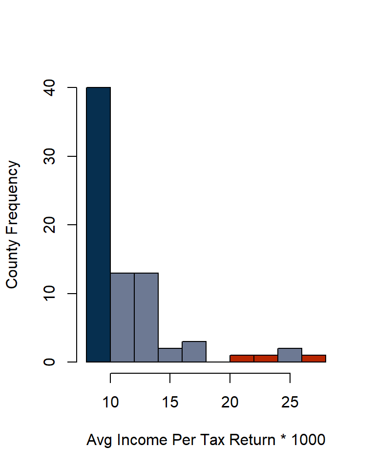

Plotting a histogram of the average income per tax returns for these years shows us that the majority of households fall between $8000 and $14000.

The lowest county being *Madison County* in 2011, and the highest with *Williamson County* in 2015.

According to the Census ACS 1-year survey, the median household income for Tennessee was $48,547 in 2016, the latest figures available. Compared to the median US household income, Tennessee median household income is $9,070 lower.

> ```
> Change in Income (2011-2015)
> ```

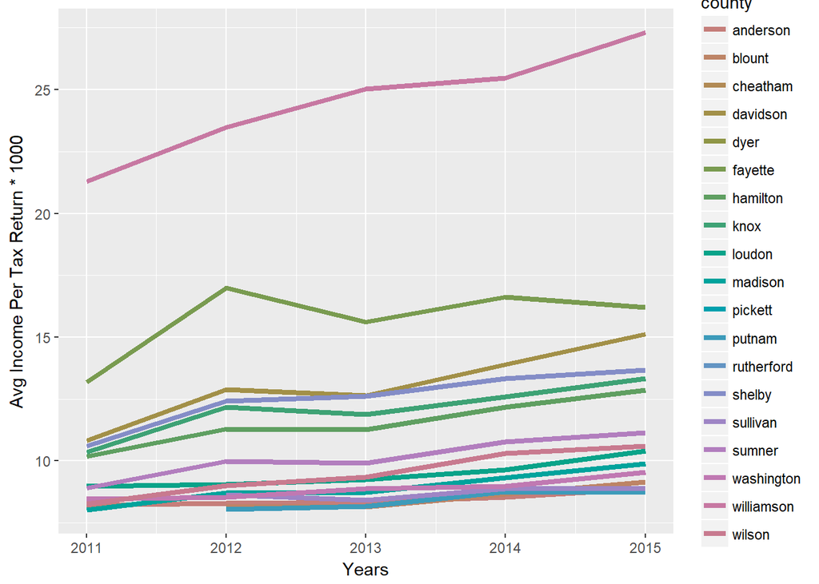

** The majority of counties maintain their rank amongst other counties.

> ```
> Counties With the Highest Number of Tax Filers Per Year
> ```

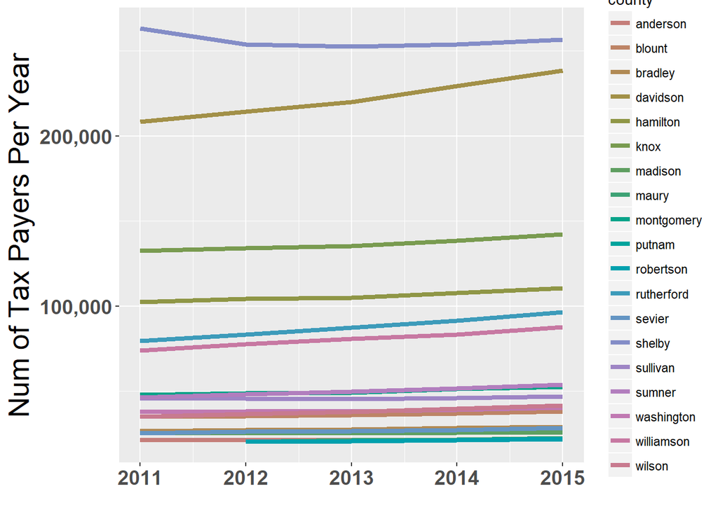

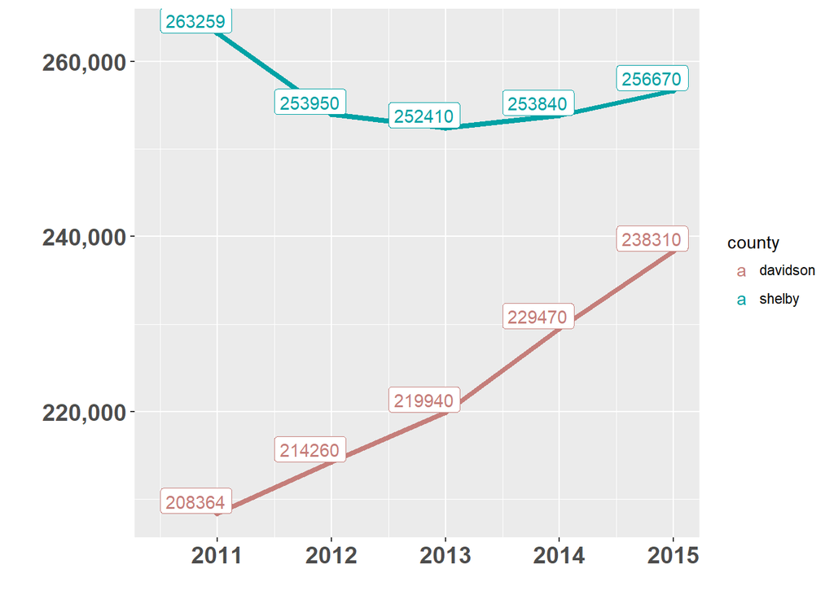

**Nashville/Davidson County’s** growth is no surprise. Both the cost of survival and downtown traffic can tell you this much. By the looks of these graphs (and now personal knowledge as a resident in 2018), we can assume the population growth is only going to increase.

*Shelby County*, on the other hand, is another story. This county has the highest decrease in tax filers between these years, yet maintains the highest amount of total income returns every year.

> ```
> Overall Education Pct Regarding Student
> Graduation, Dropout, and Suspension
> ```

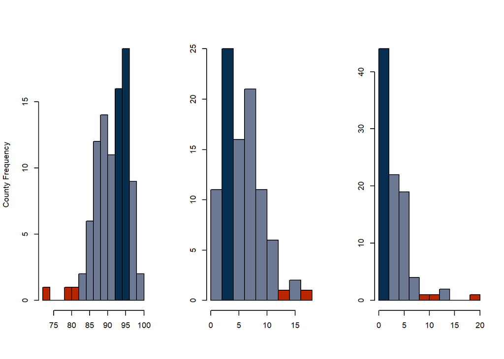

Now we get into the education data. Plotting these graphs provide some insight with regards to the highest and lowest counties.

- Graduation rate is highest in Meigs, lowest in *Shelby*.
- Dropout rate is highest in *Shelby* county, while kids are studious in Pickett and Meigs counties.
- Teachers seem to be *very* strict in *Shelby* county, since it holds the highest student suspension rate.

> ```
> Overall Education Pct Regarding Student
> ACT Scores, Math, Science, and Literature
> ```

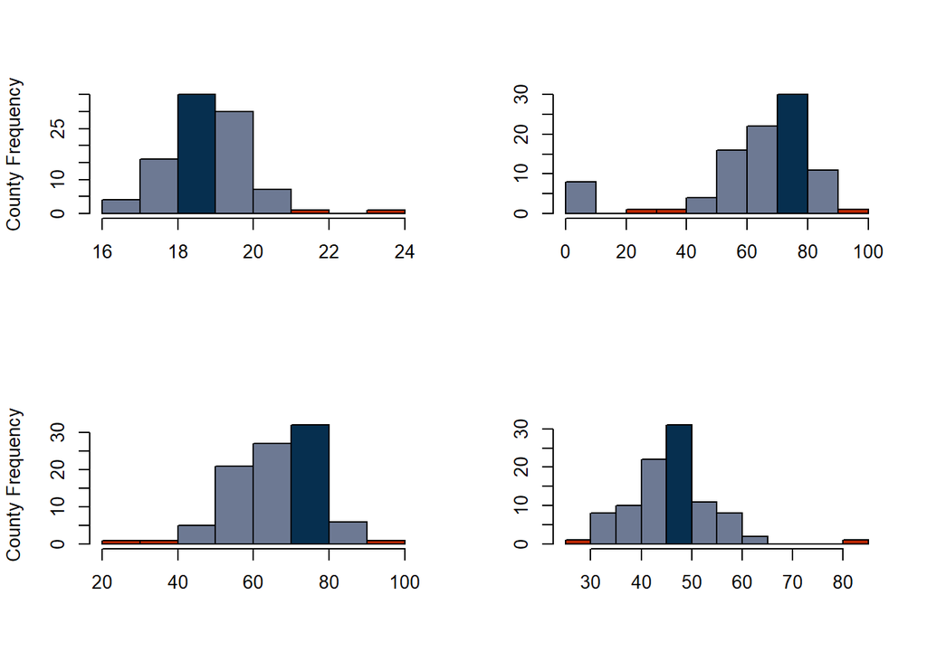

- *Williamson* county is showing highest ACT scores, average mathematics, literature, and second highest in science scores.
- The lowest ACT scores are from Lake and Fayette counties
- The lowest mathematics scores are from Cheatham and Putnam counties.
- *Fentress* takes the lead for the highest science scores at 100%, with Lake being lowest, and *Shelby* 3rd lowest.
- The lowest literature scores are from Hancock county.

Ok.. So now we are starting to see a trend. Both Shelby and Williamson County have appeared multiple times in our research. Are there any commonalities?

[figure not shown]

> ```
> Average ACT Scores Per Core Region Within TN
> ```

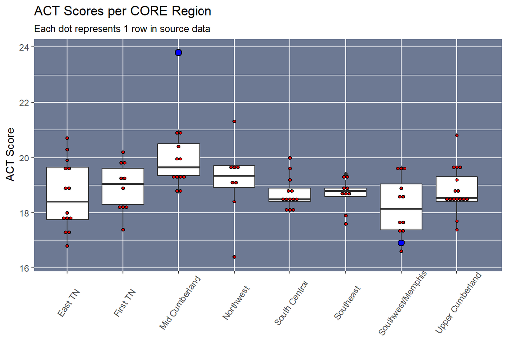

*Mid Cumberland* show the highest average overall, which also includes *Williamson* county.

Can you guess who falls within the Southwest Memphis region?? I’ll give you a hint.

It starts with *“Shel”* and ends with *“by”*..

> ```
> Income VS. Dropout, Graduation, ACT Scores
> ```

**Low: `<= 40.87K` / Mid: `> 40.87K` / High: `> 48.56K` / Very High: `> 60K`**

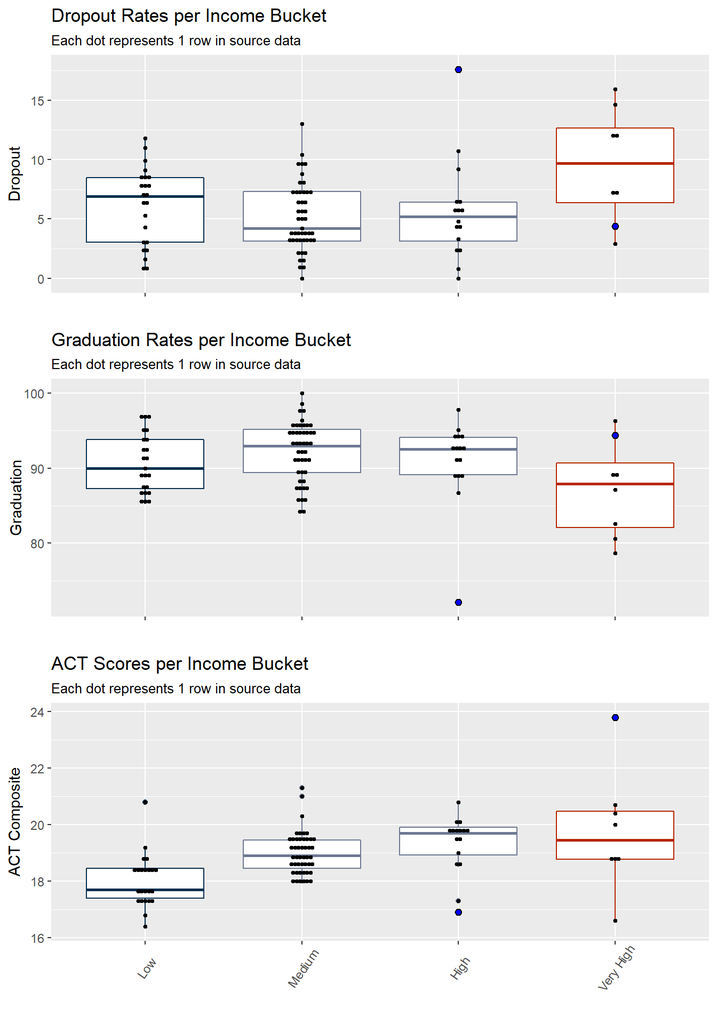

Now we get into the interesting stuff.

> ```
> Act Scores Black and Hispanic Populations
> ```

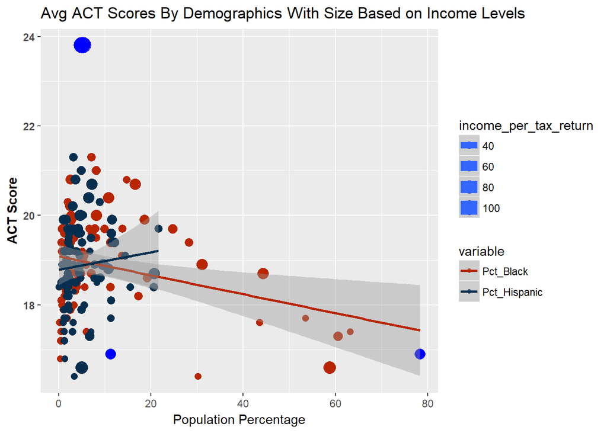

This graph really helps paint a better picture regarding ACT vs Income, while also incorporating racial demographics as a factor.

With color relating to race, and size shown by income levels, you can pretty clearly see that there is not a consistent trend regarding income. There are some counties with a high income level doing *FANTASTIC* on the ACT (such as *Williamson* at *23.8*), as well as some mid level counties. Similarly, there are some higher incomes doing *POORLY* on the ACT.

However, there does seem to be at least a small, but not insignificant, correlation between the racial population and education levels within counties. As this graph portrays, counties with a higher black population tend to do worse on the ACT vs the hispanic population, with the highest being.. **>*Shelby*** at *78.4%* black population.

> ```
> Correlation Among Variables
> ```

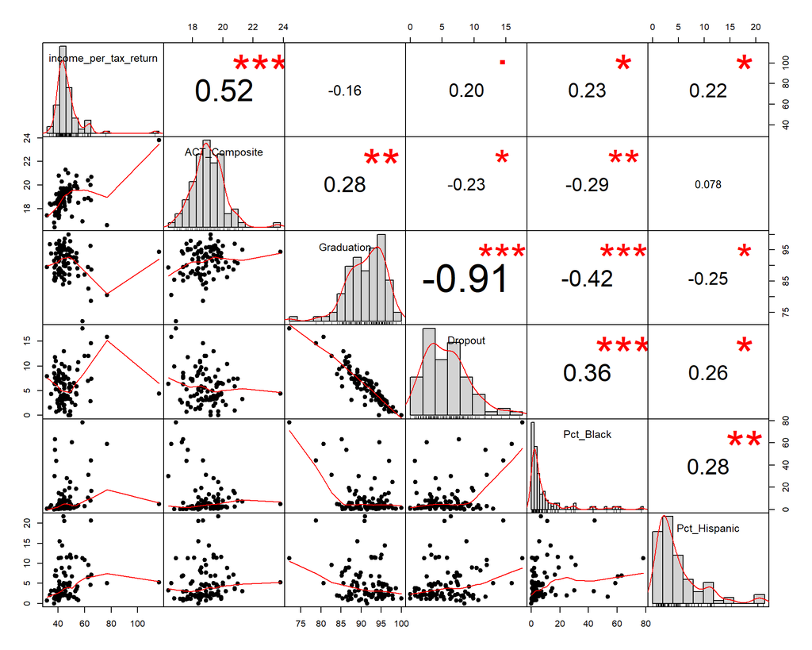